# Untitled (1)

## PRÁCTICA 2: Computación Numérica. Curso 2021-2022

### Guillermo Hoyo Bravo, Adrián Rubio Pintado

```python
import scipy.stats
import matplotlib.pyplot as plt
import numpy as np
# for latex equations
from IPython.display import Math, Latex
# for inline plots in jupyter
if True:
    %matplotlib inline
else:
    %matplotlib notebook
from scipy import integrate
```

```python
np.random.seed(124)  # semilla para reproducibilidad
```

```python
#Versión modificada de el profesor
def resultados (x, y, n, alpha) :
    z_alpha = scipy.stats.norm.ppf(1 - (alpha / 2) )
    size = np.arange (start = 1, stop = n+1,  step=1)

    # media muestral
    media = np.cumsum (y) / size

    # Varianza muestral, s2
    media2 = media * media
    y2 = y * y
    s2 = np.cumsum (y2) / size - media2

    # varianza estimador
    sigma2 = s2 /  size

    #intervalo de confianza
    sigma = np.sqrt(sigma2)
    ci_inf = media - z_alpha * sigma
    ci_sup = media + z_alpha * sigma

    resul = {'size':size, 'media' : media, 's2': s2, 'sigma2': sigma2,
             'ci_inf': ci_inf, 'ci_sup':ci_sup, 'inter_conf':z_alpha * sigma}

    return resul
```

## EJERCICIO 1

Estimar la probabilidad de que un paciente ingresado en planta acabe en la UCI. Para realizar este problema mediante inferencia Bayesiana debemos tener en cuenta: *La probabilidad de que un paciente ingresado en planta acabe en la UCI será nuestro parámetro $\theta$. Como hemos visto, en el enfoque bayesiano debemos considerar que $\theta$ es una variable aleatoria.* Debemos conocer la distribución de la v.a $\theta$ **antes** de realizar el experimento, es decir su *densidad de probabilidad a priori* $\pi(\theta)$. Supongamos, por ejemplo, que $\pi(\theta) = B(\theta | \alpha = 5, \beta = 10)$. *Debemos incorpora el resultado del experimento. Considerad el siguiente experimento: se contabiliza cuantos de los pacientes que hay en planta ($n$) deben ingresar en la UCI ($k$). Se observa que de los $n=20$ pacientes en planta $k=1$ ingresan en la UCI.* Debemos calcular la función de verosimilitud $\pi(x | \theta)$ del resultado del experimento. La función de verosimilitud será proporcional a la probabilidad de observar el resultado del experimento en función del valor de $\theta$): $$ \pi(x | \theta) \propto \theta^k (1-\theta)^{n-k} $$ donde, en este caso, habría que substituir $n=20$ y $k=1$. Notad como en la ecuación anterior $\pi(x|\theta)$ **no** está normalizada. *Debemos elegir un* predictor *adecuado a nuestro problema. Como predictor de $\theta$* la probabilidad de que un paciente de la planta acabe en la UCI* utilizaremos su valor esperado $E[\theta]$. Nos preguntarnos entonces: 1. ¿Cuál es el valor de $E[\theta]$ **antes** de realizar el experimento?

**1 ¿Cuál es el valor de E[θ] antes de realizar el experimento?**

Al ser la distribución a priori $\pi(\theta)$ la distribución $Beta$, su valor esperado será

$$ \mu_{\text{prior}} = E[\theta]_{\text{prior}} = \int_{-\infty}^{\infty} \theta \; B(\theta | \alpha, \beta) \; d\theta = \frac{\alpha}{\alpha + \beta} $$

Dado que tenemos $\alpha$ = 5 y $\beta$ = 10, tenemos que: $$ E[\theta]_{\text{prior}} = 5/ (5+10) = 0.33333333333 periodico $$

Graficamos la función de distribución a priori beta con los parámetros dados

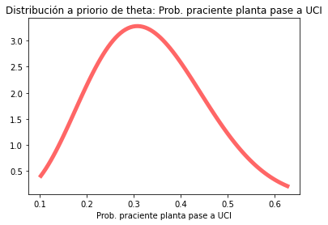

```python
a = 5
b = 10

beta = scipy.stats.beta(a,b)
fig, ax = plt.subplots(1, 1)
x = np.linspace(beta.ppf(0.01), beta.ppf(0.99), 100)
ax.plot(x, scipy.stats.beta.pdf(x, a, b), 'r-', lw=5, alpha=0.6, label='prior π(θ)')
ax.set_xlabel('Prob. praciente planta pase a UCI')
plt.title('Distribución a priorio de theta: Prob. praciente planta pase a UCI')
```

**2. ¿Cuál es el valor de $E[\theta]$ después de observar el resultado del experimento?**

Utilizando el teorema de Bayes, tras re-ordenar términos se obtiene: \begin{align} E[\theta]_{\text{posterior}} &= \int_{-\infty}^{\infty} \theta \; \pi(\theta | x) \; d\theta \\ &= \int_{-\infty}^{\infty} \theta \; \frac{ \pi(x | \theta) \; \pi(\theta) } { \int_{-\infty}^{\infty} \pi(x | \theta) \pi(\theta) \; d\theta} \; d\theta = \frac{ \int_{-\infty}^{\infty} \theta \; \pi(x | \theta) \; \pi(\theta) \; d\theta } { \int_{-\infty}^{\infty} \pi(x | \theta) \; \pi(\theta) \; d\theta} \\ &= \frac{\int_{-\infty}^{\infty} \theta \; \theta^k (1-\theta)^{n-k} \; \; \pi(\theta) \; d\theta } { \int_{-\infty}^{\infty} \pi(x | \theta) \; \pi(\theta) \; d\theta} = \frac{ \int_{0}^{1} \; \theta^{k+1} (1-\theta)^{n-k} \; \; B(\theta| \alpha=5, \beta=10) \; d\theta } { \int_{0}^{1} \theta^{k} (1-\theta)^{n-k} \; B(\theta| \alpha=5, \beta=10) \; d\theta} \end{align} donde se han sustituído los valores de $\pi(\theta)$ y de la verosimilitud $\pi(x|\theta)$ .

Para calcular dicho cociente, vamos a estimar el numerador y el denominador mediante integración de Monte Carlo. Para ello vamos a emplear el método de la función de importancia.

```python
a = 5
b = 10

n_simul = 100000 #numer of simulations

#Utilzamos muestreo por importancia

g_numerador = lambda x : (x**(k+1)) *((1 - x)**(n-k))
g_denominador = lambda x : (x**(k)) *((1 - x)**(n-k))

g_numerador_final = lambda x : g_numerador(x)   * scipy.stats.beta.pdf(x,a,b)
g_denominador_final = lambda x : g_denominador(x)  * scipy.stats.beta.pdf(x,a,b)

#  Cociente g(x) / f(x)
def h(x, g, f, a,b) :
    return g(x) /  f(x, a, b)

def verosimilitud(t,k,n):
    #print("t",t ,"k",k ,"n",n )
    #print("verosimilitud", (t**k)*((1-t)**(n-k))
    return (t**k)*((1-t)**(n-k))
```

Definimos una función para estimar por MonteCarlo la función de probabilidad a posteriori:

```python
def get_posteriori_simulacion_montecarlo(a,b, n,k,nsimul,alpha_ic):


	#Utilizamos simulación de Monte Carlo mediante función de importancia
	x =scipy.stats.beta.rvs(a, b, size=n_simul)
	y_numerador = h(x = x, g = g_numerador_final, f = scipy.stats.beta.pdf, a = a, b = b)
	y_denominador = h(x = x, g = g_denominador_final, f = scipy.stats.beta.pdf, a = a, b = b)

	e_posteriori_20_1 = np.mean(y_numerador)/np.mean(y_denominador)
	#print('Expected probability a posteriori', e_posteriori_20_1  )


	# Evolución de E[theta] en función del número de simulaciones
	y_numerador_estimador=  np.cumsum (y_numerador) / n_simul
	y_denominador_estimado=  np.cumsum (y_denominador) / n_simul
	y_final = y_numerador_estimador/y_denominador_estimado
	#r_norm = resultados(x=x, y=y_final, n=n_simul, alpha=0.05)
	r_norm = resultados(x=x, y=y_final, n=n_simul, alpha=alpha_ic)

	print('Expected probability a posteriori', y_final[-1] , ' +- ', r_norm['inter_conf'][-1])
	print('Confidence interval α =', alpha_ic)
	print('Maximum likelihood:', (k/n))
	print('Experimento:')
	print('\t Total pacientes:', n, 'UCI: ',k)



	#fig, ax = plt.subplots(1,1,  figsize=(10, 3))
	fig, ax = plt.subplots()

	desde = 1000

	#ax.plot (r_norm['size'][desde:], r_norm['media'][desde:], lw=1.0,label='Expected probability a posteriori' )

	ax.plot (r_norm['size'][desde:], r_norm['media'][desde:],  c='red' ,linestyle='dotted', lw=0.3,label = 'Estimación')
	ax.plot (r_norm['size'][desde:], r_norm['ci_inf'][desde:], c='blue', alpha=0.4, lw=0.2,label = 'I. Confianza')
	ax.plot (r_norm['size'][desde:], r_norm['ci_sup'][desde:], c='blue', alpha=0.4, lw=0.2 ,label = 'I. Confianza')
	ax.fill_between(r_norm['size'][desde:],r_norm['ci_inf'][desde:],r_norm['ci_sup'][desde:], alpha=0.4 )
	#ax.hlines(1, 0, n, linestyles='dashed', lw=0.8)
	ax.set_xlabel('Montecarlo sample size')
	ax.set_ylabel('Expected probability a posteriori')
	ax.legend(loc='best', frameon=False)
	ax.grid(lw=0.2)
	ax.set_title('Estimación de probabilidad de theta a posteriori por Monte Carlo')
	#ax.set_ylim(0, 0.4)
	plt.show()

	fig, ax = plt.subplots()
	desde = int(nsimul/2)
	ax.plot (r_norm['size'][desde:], r_norm['media'][desde:],  c='red' ,linestyle='dotted', lw=0.3,label = 'Estimación')
	ax.plot (r_norm['size'][desde:], r_norm['ci_inf'][desde:], c='blue', alpha=0.4, lw=0.2,label = 'I. Confianza')
	ax.plot (r_norm['size'][desde:], r_norm['ci_sup'][desde:], c='blue', alpha=0.4, lw=0.2 ,label = 'I. Confianza')
	ax.fill_between(r_norm['size'][desde:],r_norm['ci_inf'][desde:],r_norm['ci_sup'][desde:], alpha=0.4 )
	#ax.hlines(1, 0, n, linestyles='dashed', lw=0.8)

	ax.set_xlabel('Montecarlo sample size')
	ax.set_ylabel('Expected probability a posteriori')
	ax.legend(loc='best', frameon=False)
	ax.grid(lw=0.2)
	ax.set_title('Estimación de probabilidad de theta a posteriori por Monte Carlo')
	#ax.set_ylim(0, 0.4)
	plt.show()
```

```
Expected probability a posteriori 0.17174669634818532  +-  9.756707095564671e-06
Confidence interval α = 0.22
Maximum likelihood: 0.05
Experimento:
	 Total pacientes: 20 UCI:  1
```

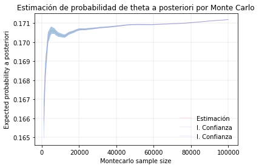

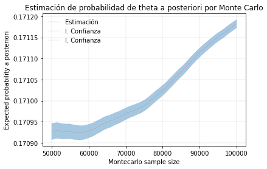

```python
n = 20
k = 1
n_simul = 100000
alpha_ic = 0.22
get_posteriori_simulacion_montecarlo(a,b,n,k,n_simul,alpha_ic)
```

```
Expected probability a posteriori 0.08598439361655257  +-  5.964026374634053e-06
Confidence interval α = 0.22
Maximum likelihood: 0.05
Experimento:
	 Total pacientes: 100 UCI:  5
```

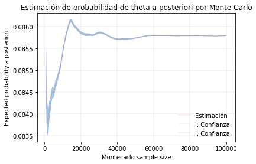

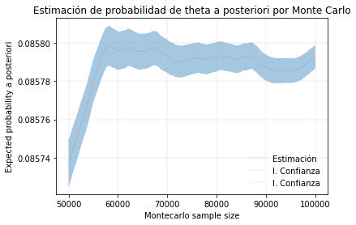

```python
n = 20*5
k = 1*5
n_simul = 100000
alpha_ic = 0.22
get_posteriori_simulacion_montecarlo(a,b,n,k,n_simul,alpha_ic)
```

Vemos como tras conocer los resultados del experimento, actualizamos la información de la que disponemos, y el valor esperado de nuestra variable aleatoria theta cambia. Además, gracias al método de Monte Carlo, hemos podido calcular el valor esperado de θ a posteriori sin necesidad de disponer de una muestra de la distribución a posteriori π(θ|x)

## Cuestiones:

**¿Por que se debe utilizar la misma muestra de θ en el numerador y denominador para estimar μposterior ?**

Porque la distribución a priori π(θ) es una distribución Beta(θ|α,β), y la función de verosimilitud vemos que es proporcional a la probabilidad de observar el resultado del experimento en función del valor de θ ) Dado que π(x|θ) está dada por (5), la distribución a posteriori π(θ|x) tiene una expresión cerrada. En este caso π(θ|x) es también una distribución Beta (se dice que ambas son conjugadas a priori).

**Siempre debes validar tu simulación:**

**En este caso puedes validar tu simulación frente al resultado teórico conocido ¿Se comporta correctamente tu estimación cuando aumenta el tamaño del experimento?**

Definimos las funciones que nos dan la probabilidad a priori/posteriori de forma teórica.

```python
def prob(a,b):
    return a/(a+b)
```

Dado que la probabilidad a priori solo depende de alpha y de beta,no de n ni de k, validamos el resultado para los 2 casos de estudio:

```python
print('Probabilidad a priori(Teórica): ',prob(a,b))
```

```
Probabilidad a priori(Teórica):  0.3333333333333333
```

Validamos ahora la probabilidad a posteriori, la cuál sí depende de n y de k:

```python
def posteriori_parameters(a, b, n, k):
    alphap = a + k
    betap = b + n - k

    return alphap, betap
```

```python
#Caso n=20, k= 1
n=20
k= 1

aa, bb = posteriori_parameters(a, b, n, k)
post = prob(aa, bb)
print('Experimento:')
print('\t Total pacientes:', n, 'UCI: ',k)
print('Probabilidad a posteriori(Estimada)', e_posteriori_20_1)


print('\nProbabilidad a posteriori(Teórica): ',post)
print('Error cometido(Teorico vs estimacion): ', abs(post - e_posteriori_20_1))

i_numeric = integrate.quad(g_numerador_final,0,1)[0]
i_numeric2 = integrate.quad(g_denominador_final,0,1)[0]

print('\nProbabilidad a posteriori(Teórica por integración numerica)', i_numeric/i_numeric2 )
print('Error cometido(Integración vs estimacion): ', abs(post - i_numeric/i_numeric2))
```

```
Experimento:
	 Total pacientes: 20 UCI:  1
Probabilidad a posteriori(Estimada) 0.17165447893335062

Probabilidad a posteriori(Teórica):  0.17142857142857143
Error cometido(Teorico vs estimacion):  0.00022590750477918808

Probabilidad a posteriori(Teórica por integración numerica) 0.17142857142857143
Error cometido(Integración vs estimacion):  0.0
```

```python
#Caso n=100, k = 5
n=100
k = 5
aa, bb = posteriori_parameters(a, b, n, k)
post = prob(aa, bb)
print('Experimento:')
print('\t Total pacientes:', n, 'UCI: ',k)
print('Probabilidad a posteriori(Estimada)', e_posteriori_100_5)


print('\nProbabilidad a posteriori(Teórica): ',post)
print('Error cometido(Teorico vs estimacion): ', abs(post - e_posteriori_20_1))

i_numeric = integrate.quad(g_numerador_final,0,1)[0]
i_numeric2 = integrate.quad(g_denominador_final,0,1)[0]

print('\nProbabilidad a posteriori(Teórica por integración numerica)', i_numeric/i_numeric2 )
print('Error cometido(Integración vs estimacion): ', abs(post - i_numeric/i_numeric2))
```

```
Experimento:
	 Total pacientes: 100 UCI:  5
Probabilidad a posteriori(Estimada) 0.08681814779469985

Probabilidad a posteriori(Teórica):  0.08695652173913043
Error cometido(Teorico vs estimacion):  0.08469795719422019

Probabilidad a posteriori(Teórica por integración numerica) 0.08695645045706057
Error cometido(Integración vs estimacion):  7.128206985784757e-08
```

**¿Cómo de fiable es la estimación del error que hemos hecho? Discute que valor de zα/2 es apropiado. ....y algo mas**

El error de nuestro estimador 𝑆𝑛 dependerá del tamaño de la muestra 𝑛 y de la varianza de la v.a h(x) = g(x)/f(x) para cada integral. Suponemos que Z es el cociente de dos v.a Z=X/Y(integral estimada en el numerador y la estimada también en el denominador) e interpretamos X e Y como una medida con un error asociado ( x±δx , x±δx ).

Es decir, dichas medidas las tomaremos como las medias muestrales(salida de nuestras estimaciones Monte Carlo) junto con su intervalo de confianza para un α dado.

Entonces el error máximo sería en el peor de los casos cuando ambos errores se suman al ser un cociente. Es decir, tendríamos: $$δz/z=δx/x+δy/y$$

```python
def get_posteriori_propagacion_error_maxima(a,b, n,k,nsimul,alpha_ic):


	#Utilizamos simulación de Monte Carlo mediante función de importancia
	x =scipy.stats.beta.rvs(a, b, size=n_simul)
	y_numerador = h(x = x, g = g_numerador_final, f = scipy.stats.beta.pdf, a = a, b = b)
	y_denominador = h(x = x, g = g_denominador_final, f = scipy.stats.beta.pdf, a = a, b = b)


	# Evolución de E[theta] en función del número de simulaciones
	y_numerador_estimador=  np.cumsum (y_numerador) / n_simul
	y_denominador_estimado=  np.cumsum (y_denominador) / n_simul
	y_final = y_numerador_estimador/y_denominador_estimado
	#r_norm = resultados(x=x, y=y_final, n=n_simul, alpha=0.05)
	r_norm_num = resultados(x=x, y=y_numerador_estimador, n=n_simul, alpha=alpha_ic)
	r_norm_denom = resultados(x=x, y=y_denominador_estimado, n=n_simul, alpha=alpha_ic)
	r_norm_total = resultados(x=x, y=y_final, n=n_simul, alpha=alpha_ic)


	#Sacamos los términos del error para el tamaño mas grande de la simulación
	x = y_numerador_estimador[-1]
	d_x=r_norm_num['inter_conf'][-1]
	y = y_denominador_estimado[-1]
	d_y = r_norm_denom['inter_conf'][-1]

	suma_propagacion_errores = (d_x/x) + (d_y/y)
	print('Peor caso propagación de errores(suma numerador y denominador):',suma_propagacion_errores)

	#suma_z_propagacion_errores = (d_z/z)
	#z=y_final[-1]
	#d_z=r_norm_total['inter_conf'][-1]
	#print('Peor caso propagación de errores(Cociente):', suma_z_propagacion_errores)

	print('\n\nExpected probability a posteriori', y_final[-1] , ' +- ', r_norm['inter_conf'][-1])
	print('Confidence interval α =', alpha_ic)
	print('Experimento:')
	print('\t Total pacientes:', n, 'UCI: ',k)
```

```python
n = 20*5
k = 1*5
n_simul = 100000
alpha_ic = 0.05
get_posteriori_propagacion_error_maxima(a,b,n,k,n_simul,alpha_ic)
```

```
Peor caso propagación de errores(suma numerador y denominador): 0.003547076728133547


Expected probability a posteriori 0.08635648830119663  +-  4.961932584470011e-06
Confidence interval α = 0.05
Experimento:
	 Total pacientes: 100 UCI:  5
```

Observamos como en el peor de lo casos, la propagación máxima de ambas variables aleatorias es de 0.003547076728133547. Por ello, deberíamos escoger un intervalo de confianza más ajustado que dicho error, para poder minimizarlo, y dar un buen estimador.

Vemos que cogiendo un α = 0.05, obtenemos u intervalo de confianza con exponente e-06, es decir, más pequeño que el error máximo con exponente e-03, por lo que podemos decir que α = 0.05 es un valor apropiado para el intervalo de confianza.

Vemos como a nivel práctico el error cometido es muy pequeño y el intervalo de confianza está bastante ajustado(se ajusta a cifras decimales a partir de orden 3). Por ello podemos concluir que el estimador que hemos proporcionado es bastante fiable.

**Supón que no se dispone de un generador de números aleatorios para la distribución a priori (porqué o bien no dispones de un algoritmo o este es muy ineficaz) ¿Podrías estimar μposterior ? Estima el valor de μposterior sin utilizar el generador de una muestra de Beta (por ejemplo utiliza una distribución U(0,1) ). Discute el intervalo de confianza de la estimación.**

Utilizamos el metodo de la inversa, para generar una muestra de la distribución beta a través de su función de distribución inversa. Definimos para ello la función apropiada. Si nos fijamos, el cambio con el caso anterior es que ahora generamos una muestra de la distribución uniforme, y le pasamos dicha muesta a la función de distribución inversa de la distribució Beta.

El resto del proceso es igual al caso anterior

```python
def get_posteriori_muestreo_uniforme(a,b, n,k,n_simul,alpha_ic):

	#Utilizamos simulación de Monte Carlo mediante función de importancia
	x_uniform = scipy.stats.uniform.rvs(loc=0, scale=1, size=n_simul)
	x = scipy.stats.beta.ppf(x_uniform,a,b)


	y_numerador = h(x = x, g = g_numerador_final, f = scipy.stats.beta.pdf, a = a, b = b)
	y_denominador = h(x = x, g = g_denominador_final, f = scipy.stats.beta.pdf, a = a, b = b)

	# Evolución de E[theta] en función del número de simulaciones
	y_numerador_estimador=  np.cumsum (y_numerador) / n_simul
	y_denominador_estimado=  np.cumsum (y_denominador) / n_simul
	y_final = y_numerador_estimador/y_denominador_estimado
	r_norm = resultados(x=x, y=y_final, n=n_simul, alpha=0.05)

	print('\n\nExpected probability a posteriori', y_final[-1] , ' +- ', r_norm['inter_conf'][-1])
	print('Confidence interval α =', alpha_ic)
	print('Maximum likelihood:', (k/n))
	print('Experimento:')
	print('\t Total pacientes:', n, 'UCI: ',k)


	fig, ax = plt.subplots()

	desde = 1000


	ax.plot (r_norm['size'][desde:], r_norm['media'][desde:],  c='red' ,linestyle='dotted', lw=0.3,label = 'Estimación:Expected probability a posteriori')
	ax.plot (r_norm['size'][desde:], r_norm['ci_inf'][desde:], c='blue', alpha=0.4, lw=0.2,label = 'I. Confianza')
	ax.plot (r_norm['size'][desde:], r_norm['ci_sup'][desde:], c='blue', alpha=0.4, lw=0.2 ,label = 'I. Confianza')
	ax.fill_between(r_norm['size'][desde:],r_norm['ci_inf'][desde:],r_norm['ci_sup'][desde:], alpha=0.4 )
	#ax.hlines(1, 0, n, linestyles='dashed', lw=0.8)
	ax.set_xlabel('Montecarlo sample size')
	ax.set_ylabel('Expected probability a posteriori')
	ax.legend(loc='best', frameon=False)
	ax.grid(lw=0.2)
	ax.set_title('Estimación de probabilidad de theta a posteriori por Monte Carlo')
	#ax.set_ylim(0, 0.4)
	plt.show()

	fig, ax = plt.subplots()
	desde = int(n_simul/2)
	ax.plot (r_norm['size'][desde:], r_norm['media'][desde:],  c='red' ,linestyle='dotted', lw=0.3,label = 'Estimación:Expected probability a posteriori')
	ax.plot (r_norm['size'][desde:], r_norm['ci_inf'][desde:], c='blue', alpha=0.4, lw=0.2,label = 'I. Confianza')
	ax.plot (r_norm['size'][desde:], r_norm['ci_sup'][desde:], c='blue', alpha=0.4, lw=0.2 ,label = 'I. Confianza')
	ax.fill_between(r_norm['size'][desde:],r_norm['ci_inf'][desde:],r_norm['ci_sup'][desde:], alpha=0.4 )
	#ax.hlines(1, 0, n, linestyles='dashed', lw=0.8)

	ax.set_xlabel('Montecarlo sample size')
	ax.set_ylabel('Expected probability a posteriori')
	ax.legend(loc='best', frameon=False)
	ax.grid(lw=0.2)
	ax.set_title('Estimación de probabilidad de theta a posteriori por Monte Carlo(Generador muestras uniforme)')
	#ax.set_ylim(0, 0.4)
	plt.show()
```

```
Expected probability a posteriori 0.1730841585585165  +-  9.495093233396467e-05
Confidence interval α = 0.05
Maximum likelihood: 0.05
Experimento:
	 Total pacientes: 20 UCI:  1
```

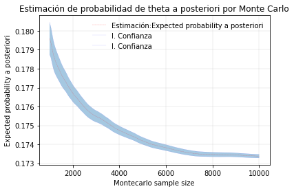

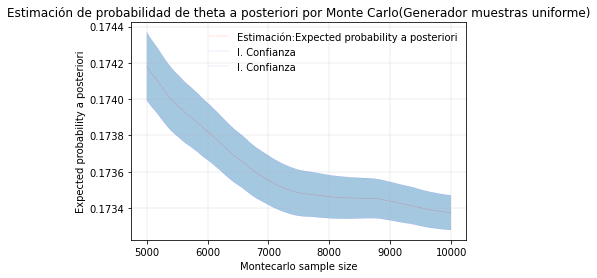

```python
n = 20
k = 1
n_simul = 10000
alpha_ic = 0.05
get_posteriori_muestreo_uniforme(a,b, n,k,n_simul,alpha_ic)
```

```
Expected probability a posteriori 0.08472453723048073  +-  0.00015046172479600108
Confidence interval α = 0.05
Maximum likelihood: 0.05
Experimento:
	 Total pacientes: 100 UCI:  5
```

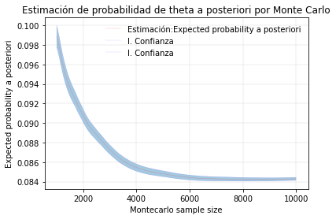

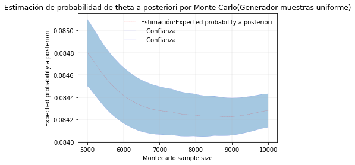

```python
n = 20*5
k = 1*5
n_simul = 10000
get_posteriori_muestreo_uniforme(a,b, n,k,n_simul,alpha_ic)
```

A efectos prácticos vemos como ambos métodos son equivalentes(usar generador de la distribución vs. usar muestra uniforme + función de distrib. inversa).

Es decir, que aunque a efectos prácticos son equivalentes, lo cierto es que obtenemos un error ligeramente menor utilizando el generador de muestras propio de la distribución

## EJERICICIO 2

**Estimar empíricamente la función de densidad de probabilidad a posteriori π(θ|x) del ejercicio anterior y validarla con el resultado teórico. Discutir los resultados**

Para resolver este ejercicio hemos utilizado el algoritmo de aceptación y rechazo. Este algoritmo se basa en generar muestras de una uniforme, de manera que si una muestra de nuestra distribución, dividida por una constante C, es mayor que una muestra de la distribución uniforme, esta muestra se acepta. Si por el contrario nuestra muestra es menor, está será rechazada. Es decir:

$$u \in \mathcal{U}(0,1)$$

$$b \in \mathcal{B}(\alpha, \beta)$$ $$C = Constante => C = Maxima Verosimilitud = k/n$$

El algoritmo resulta del siguiente modo: 1: Calcular C = k/n = NºCasos/NºMuestras 2: Calcular muestra de distribución Beta($\alpha=5$,$\beta=10$) = b 3: Calcular muestra de distribución Uniforme(0,1) = u 4: Si u < b/C => b se acepta.

Una vez terminado este algoritmo con la ayuda de scipy, pasamos a calcular la eficiencia y realizamos el test de kolmogorov.

Este test nos ayuda a contrastar si neustra muestra es ideal o compatible a la hora de compararla con la el valor de la distribución teórica. Este test se basa en estimar la distancia máxima entre la muestra obtenida y una $\mathcal{U}(0,1)$, la cual es una variable aleatoria.

El test de kolmogorov nos da 2 valores: el pvalor y las stadisticas. Un pvalor bajo significa que la probabilidad se aleja mucho de la distribución, es decir es una probabilidad muy rara para la distribución. Por tanto significa ambos grupos o distribuciones fueron sampleados de diferentes poblaciones, aunque las poblaciones pueden diferir en cuanto a medias, variabilidad o forma de la distribución. Por todo esto queremos conseguir un pvalor lo mas alto posible.

```python
def prob_aceptar_rechazar_muestra(t,cte_a, k,n):
    return verosimilitud(t,k,n)/cte_a
```

```
Eficiencia... 0.02433
```

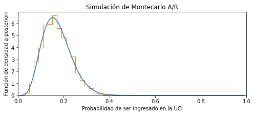

```
KstestResult(statistic=0.010107719753527089, pvalue=0.9627216497935536)
```

```python
n_simul = 100000
n = 20
k = 1

#cte_a = verosimilitud(k/n, k,n   )
cte_a = k/n


# Generamos una muestra de la distrib. a priori
x = scipy.stats.beta.rvs(a, b, size=n_simul)
# print(len(x), x)

probs_x = prob_aceptar_rechazar_muestra(x,cte_a,k,n)
probs_u = scipy.stats.uniform.rvs(size=n_simul)
muestras_distrib = []
for z,p,u in zip(x,probs_x,probs_u):

    if(u < p):
        muestras_distrib.append(z)

print('Eficiencia...',len(muestras_distrib)/n_simul)

# Gráfica
fig, ax=plt.subplots(1, figsize=(8,3))
w = np.linspace(0.01, 0.99, 100)

ax.plot(w, scipy.stats.beta.pdf(w, a+k, b+n-k))
ax.hist(muestras_distrib, histtype='step', bins=20, density=True, linewidth=1, label='Sample')
plt.xlim(0, 1)

plt.ylabel('Función de densidad a posteriori')
plt.xlabel('Probabilidad de ser ingresado en la UCI')
plt.title('Simulación de Montecarlo A/R')

plt.show()

print(scipy.stats.kstest(muestras_distrib, 'beta', args=(a+k, b+n-k)))
```

*Metropolis-Hasting*

Existen otros algorimos de MCMC que realizan lo mismo que hemos contemplado con el algoritmo aceptación y rechazo. Uno de los ams famosos es el algoritmo metropolis-hasting, usando kadenas de markov.

Queremos obtener muestras de una distribución p(x), pero no conocemos la distribución, solo conocemos el numerador f(x), de forma que: $$ p(x) = f(x)/c$$

Por lo tanto buscamos conseguir muestras de p(x) unicamente con f(x). para ello, se usa una cadena de markov que consigue unas primeras muestras poco acertadas al modelo (llamadas burn-in), pero a medida que se generan mas, las muestras generadas son como las de p(x). Este punto de roptura en el que se empiezan a tratar las muestras como de la propia distribución p(x) se llama Xb.

Para realizar esto, a M-H se le propone un nuevo candidato a proponer, como en aceptación y rechazo. En Aceptación y rechazo esta propuesta es independiente, pero en M-H se utiliza la media de una distribución normal $\mathcal{N}(x_t,\sigma^2)$, o una mas sencilla de extraer muestras, de manera que sea la muestra exacta anterior considerada. De manera que $g(x_{t-1}|x_t)$

El siguiente paso es aceptar este caso $x_t+1$ con la probabilidad de aceptar esa transición = $A(xt->x_t+1)$

Esto cumple una condicion equilibrada detallada que dice: que por cualquier estas: a,b $$p(a)T(a->b) = p(b)T(b->a)$$ Siendo T(a->b) la probabilidad de transitad de a a b. Con lo mencionado anteriormente llegamos a que, p(a) = f(a)/C, y T(a->b) es g(b|a)A(a->b). Es decir, la probabilidad de la transición es la probabilidad de que el estado b sea propuesto desde a, mas la probabilidad de aceptar el estado b estando en a. Por tanto: $$\frac{f(a)}{C}*g(b|a)*A(a->b) = \frac{f(b)}{C}*g(a|b)*A(b->a)$$

Despejando podemos llegar a esta equación para simplificar: $$\frac{A(a->b)}{A(b->a)} = \frac{f(b)}{f(a)}\frac{g(a|b)}{g(b|a)}$$ Donde $\frac{f(b)}{f(a)}$ = Rf = Ratio de f

Y $\frac{g(a|b)}{g(b|a)}$ = Rg = Ratio de g

La definicion del algoritmo MCMC M-H dice que:

si $Rf*Rg<1$, entonces $A(a->b) = RfRg$ y $A(b->1) = 1$

si $Rf*Rg>=1$, entonces $A(a->b) = 1$ y $A(b->1) = \frac{1}{RfRg}$

Todo esto se se puede resumir en una equcaión $$A(a->b) = Min(1, Rf Rb)$$

Como conclusión, el algoritmo M-H basicamente genera muestras acercandose cada vez mas al punto de mayor densidad de la población desconocida o propuesta, o a un punto que tiene mayor probabilidad en ella. Esto se da por la relacaión entre las muestras, estas no son independientes como en el algoritmo aceptación y rechazo. Por ello este metodo es muy poderoso y de los mas famosos hoy en día.

```python
# Ejemplo algoritmo metropolis
def metropolis(func, pasos=10000):
    """A very simple Metropolis implementation"""
    muestras = np.zeros(pasos)
    old_x = func.mean()
    old_prob = func.pdf(old_x)

    for i in range(pasos):
        new_x = old_x + np.random.normal(0, 0.5)
        new_prob = func.pdf(new_x)
        aceptacion = new_prob / old_prob
        if aceptacion >= np.random.random():
            muestras[i] = new_x
            old_x = new_x
            old_prob = new_prob
        else:
            muestras[i] = old_x

    return muestras
```

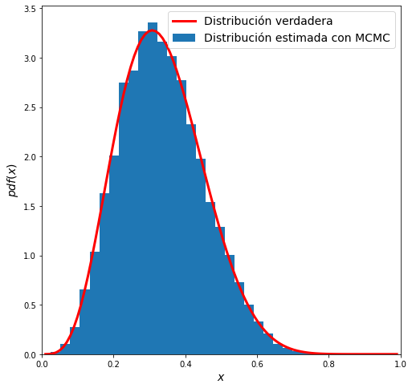

```
KstestResult(statistic=0.007328442160809606, pvalue=4.305398546390386e-05)
```

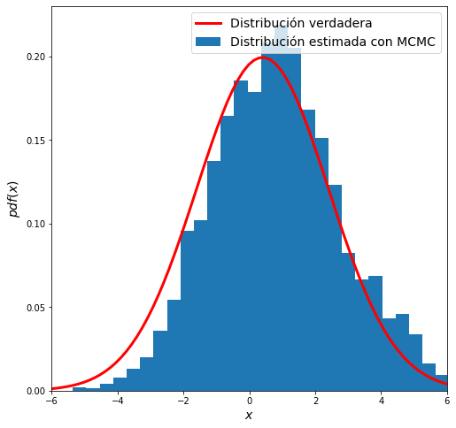

```
KstestResult(statistic=0.08291811396860688, pvalue=2.9352119948677536e-60)
```

```python
# distribución beta
beta = scipy.stats.beta(a, b)
muestras = metropolis(func = beta, pasos = 100000)
x = np.linspace(0.01, .99, 100)
y = beta.pdf(x)
plt.figure(figsize=(8, 8))
plt.xlim(0, 1)
plt.plot(x, y, 'r-', lw=3, label='Distribución verdadera')
plt.hist(muestras, bins=30, density=True, label='Distribución estimada con MCMC')
plt.xlabel('$x$', fontsize=14)
plt.ylabel('$pdf(x)$', fontsize=14)
plt.legend(fontsize=14)
plt.show()

print(scipy.stats.kstest(muestras, 'beta', args=(a, b)))


# distribución normal
norm = scipy.stats.norm(0.4, 2)
muestras = metropolis(func = norm)
x = np.linspace(-6, 10, 100)
y = norm.pdf(x)
plt.figure(figsize=(8,8))
plt.xlim(-6, 6)
plt.plot(x, y, 'r-', lw=3, label='Distribución verdadera')
plt.hist(muestras, bins=30, density=True, label='Distribución estimada con MCMC')
plt.xlabel('$x$', fontsize=14)
plt.ylabel('$pdf(x)$', fontsize=14)
plt.legend(fontsize=14)
plt.show()

print(scipy.stats.kstest(muestras, 'norm', args=(0.4, 2)))
```

Cita para Metropolis-Hasting: https://relopezbriega.github.io/blog/2017/01/10/introduccion-a-los-metodos-de-monte-carlo-con-python/